# Music Recommendation System

**Varun Nadgir**  
Applied Data Science Program 2021

```python
import warnings
warnings.filterwarnings('ignore')

# numpy, pandas for data transformation and df manipulation
import numpy as np
import pandas as pd

# matplotlib, seaborn for visualizations
import matplotlib.pyplot as plt
import seaborn as sns

# cosine similarity calculation
from sklearn.metrics.pairwise import cosine_similarity

# splitting data into train and test sets
from sklearn.model_selection import train_test_split

# RMSE and MSE success measures to judge model
from sklearn.metrics import mean_squared_error
```

```python
# import datasets
song_df = pd.read_csv('song_data.csv')
count_df = pd.read_csv('count_data.csv')

# dropping redundant index column
count_df = count_df.drop('Unnamed: 0', axis=1)
```

## 1. Exploring the Data

```python
# quick look at the df
song_df.head()
```

|  | song_id | title | release | artist_name | year |
| --- | --- | --- | --- | --- | --- |
| 0 | SOQMMHC12AB0180CB8 | Silent Night | Monster Ballads X-Mas | Faster Pussy cat | 2003 |
| 1 | SOVFVAK12A8C1350D9 | Tanssi vaan | Karkuteillä | Karkkiautomaatti | 1995 |
| 2 | SOGTUKN12AB017F4F1 | No One Could Ever | Butter | Hudson Mohawke | 2006 |
| 3 | SOBNYVR12A8C13558C | Si Vos Querés | De Culo | Yerba Brava | 2003 |
| 4 | SOHSBXH12A8C13B0DF | Tangle Of Aspens | Rene Ablaze Presents Winter Sessions | Der Mystic | 0 |

```python
# quick look at the df
count_df.head()
```

|  | user_id | song_id | play_count |
| --- | --- | --- | --- |
| 0 | b80344d063b5ccb3212f76538f3d9e43d87dca9e | SOAKIMP12A8C130995 | 1 |
| 1 | b80344d063b5ccb3212f76538f3d9e43d87dca9e | SOBBMDR12A8C13253B | 2 |
| 2 | b80344d063b5ccb3212f76538f3d9e43d87dca9e | SOBXHDL12A81C204C0 | 1 |
| 3 | b80344d063b5ccb3212f76538f3d9e43d87dca9e | SOBYHAJ12A6701BF1D | 1 |
| 4 | b80344d063b5ccb3212f76538f3d9e43d87dca9e | SODACBL12A8C13C273 | 1 |

```python
# check for missing values
song_df.isna().sum()
```

```
song_id         0
title          15
release         5
artist_name     0
year            0
dtype: int64
```

```python
# check for missing values
count_df.isna().sum()
```

```
user_id       0
song_id       0
play_count    0
dtype: int64
```

- In song_df, **Title** and **Release** columns have some null values.
- All values are present in count_df.

```python
# check how many song id are unique
print("song_df unique id count: ", song_df['song_id'].nunique())
print("count_df unique id count:", count_df['song_id'].nunique())
```

```
song_df unique id count:  999056
count_df unique id count: 10000
```

```python
# check sizes
song_rows, song_columns = song_df.shape
print("No of rows: ", song_rows)
print("No of columns: ", song_columns)

count_rows, count_columns = count_df.shape
print("No of rows: ", count_rows)
print("No of columns: ", count_columns)
```

```
No of rows:  1000000
No of columns:  5
No of rows:  2000000
No of columns:  3
```

- Out of 1,000,000 rows in song_df, only 999,056 song id are unique. This means that 944 songs in song_df have a duplicated id.

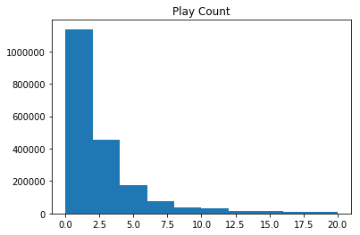

```python
# histogram of play counts
plt.hist(count_df['play_count'], range=(0,20))
plt.title("Play Count")
plt.show()
```

```python
# what does upper end look like
count_df.sort_values(by='play_count', ascending=False).head(10)
```

|  | user_id | song_id | play_count |
| --- | --- | --- | --- |
| 1228366 | d13609d62db6df876d3cc388225478618bb7b912 | SOFCGSE12AF72A674F | 2213 |
| 1048310 | 50996bbabb6f7857bf0c8019435b5246a0e45cfd | SOUAGPQ12A8AE47B3A | 920 |
| 1586780 | 5ea608df0357ec4fda191cb9316fe8e6e65e3777 | SOKOSPK12A8C13C088 | 879 |
| 31179 | bb85bb79612e5373ac714fcd4469cabeb5ed94e1 | SOZQSVB12A8C13C271 | 796 |
| 1875121 | c012ec364329bb08cbe3e62fe76db31f8c5d8ec3 | SOBONKR12A58A7A7E0 | 683 |
| 1644909 | 70caceccaa745b6f7bc2898a154538eb1ada4d5a | SOPREHY12AB01815F9 | 676 |
| 1731945 | 972cce803aa7beceaa7d0039e4c7c0ff097e4d55 | SOJRFWQ12AB0183582 | 664 |
| 1374693 | d2232ac7a1ec17b283b5dff243161902b2cb706c | SOLGIWB12A58A77A05 | 649 |
| 1819571 | f5363481018dc87e8b06f9451e99804610a594fa | SOVRIPE12A6D4FEA19 | 605 |
| 515442 | f1bdbb9fb7399b402a09fa124210dedf78e76034 | SOZPMJT12AAF3B40D1 | 585 |

- Though we have some very high play counts in our dataset, the majority of plays are less than 5.
- May need to shave off the lower end to save on computing.
- Higher number of plays also means the user is more active than someone with just 1 or 2 plays.

## 2. Cleaning the Data

```python
# drop duplicated song ids, remove year = 0 obs
song_df = song_df.drop_duplicates(subset=['title', 'artist_name'], keep=False)
song_df = song_df[song_df['year'] != 0]

song_df.head()
```

|  | song_id | title | release | artist_name | year |
| --- | --- | --- | --- | --- | --- |
| 0 | SOQMMHC12AB0180CB8 | Silent Night | Monster Ballads X-Mas | Faster Pussy cat | 2003 |
| 1 | SOVFVAK12A8C1350D9 | Tanssi vaan | Karkuteillä | Karkkiautomaatti | 1995 |
| 2 | SOGTUKN12AB017F4F1 | No One Could Ever | Butter | Hudson Mohawke | 2006 |
| 3 | SOBNYVR12A8C13558C | Si Vos Querés | De Culo | Yerba Brava | 2003 |
| 7 | SOEYRFT12AB018936C | 2 Da Beat Ch'yall | Da Bomb | Kris Kross | 1993 |

```python
count_df.head()
```

|  | user_id | song_id | play_count |
| --- | --- | --- | --- |
| 0 | b80344d063b5ccb3212f76538f3d9e43d87dca9e | SOAKIMP12A8C130995 | 1 |
| 1 | b80344d063b5ccb3212f76538f3d9e43d87dca9e | SOBBMDR12A8C13253B | 2 |
| 2 | b80344d063b5ccb3212f76538f3d9e43d87dca9e | SOBXHDL12A81C204C0 | 1 |
| 3 | b80344d063b5ccb3212f76538f3d9e43d87dca9e | SOBYHAJ12A6701BF1D | 1 |
| 4 | b80344d063b5ccb3212f76538f3d9e43d87dca9e | SODACBL12A8C13C273 | 1 |

To make our data easier to work with, I will re-index the song and user id columns. By taking their unique values, I can instead map them to integer values 0 - n where n is the number of unique ids for that column. This will avoid having to use long alphanumeric strings to find users and songs.

```python
# combine all song ids into one list
all_songs = song_df['song_id'].append(count_df['song_id'])
```

```python
# take only unique ids
song_id_list = list(np.unique(all_songs))
user_id_list = list(np.unique(count_df['user_id']))
```

```python
# create a dictionary of "original song id" : "new id"
song_id_dict = {}
song_count = 0

for songid in song_id_list:
    song_id_dict[songid] = song_count
    song_count += 1
```

```python
# create a dictionary of "original user id" : "new id"
user_id_dict = {}
user_count = 0

for userid in user_id_list:
    user_id_dict[userid] = user_count
    user_count += 1
```

```python
# run this to map original song ids to new ids based on previous dictionaries
song_df['song_id'] = song_df['song_id'].map(song_id_dict)
count_df['song_id'] = count_df['song_id'].map(song_id_dict)
count_df['user_id'] = count_df['user_id'].map(user_id_dict)
```

```python
song_df.head()
```

|  | song_id | title | release | artist_name | year |
| --- | --- | --- | --- | --- | --- |
| 0 | 291199 | Silent Night | Monster Ballads X-Mas | Faster Pussy cat | 2003 |
| 1 | 366435 | Tanssi vaan | Karkuteillä | Karkkiautomaatti | 1995 |
| 2 | 125131 | No One Could Ever | Butter | Hudson Mohawke | 2006 |
| 3 | 28698 | Si Vos Querés | De Culo | Yerba Brava | 2003 |
| 7 | 92317 | 2 Da Beat Ch'yall | Da Bomb | Kris Kross | 1993 |

```python
count_df.head()
```

|  | user_id | song_id | play_count |
| --- | --- | --- | --- |
| 0 | 54961 | 7370 | 1 |
| 1 | 54961 | 19737 | 2 |
| 2 | 54961 | 35497 | 1 |
| 3 | 54961 | 36241 | 1 |
| 4 | 54961 | 56150 | 1 |

```python
# check if any ids failed to convert (failed .map leads to NaN value)
count_df.isna().sum()
```

```
user_id       0
song_id       0
play_count    0
dtype: int64
```

```python
song_df.isna().sum()
```

```
song_id        0
title          0
release        0
artist_name    0
year           0
dtype: int64
```

- Now both dataframes have had song and user id columns re-mapped.
- There are no null values after mapping, meaning replacements were successful.

## 3. Collaborative Filtering

```python
# take subset of songs with at least 15 plays
# will help reduce processing load and will yield better results for long-term users
count_df_15 = count_df[count_df['play_count']>15]

# use pivot method to turn row-wise observations into user/item sparse matrix
interactions_matrix = count_df_15.pivot(index='user_id', columns='song_id', values='play_count')
```

```python
# replace NaN with 0 to allow for calculations
interactions_matrix.fillna(0, inplace=True)
interactions_matrix.head()
```

| song_id user_id | 6 | 64 | 66 | 146 | 174 | 296 | 328 | 428 | 500 | 550 | ... | 438363 | 438601 | 438647 | 438670 | 438709 | 438731 | 438741 | 438878 | 438887 | 438972 |
| --- | --- | --- | --- | --- | --- | --- | --- | --- | --- | --- | --- | --- | --- | --- | --- | --- | --- | --- | --- | --- | --- |
| 7 | 0.0 | 0.0 | 0.0 | 0.0 | 0.0 | 0.0 | 0.0 | 0.0 | 0.0 | 0.0 | ... | 0.0 | 0.0 | 0.0 | 0.0 | 0.0 | 0.0 | 0.0 | 0.0 | 0.0 | 0.0 |
| 10 | 0.0 | 0.0 | 0.0 | 0.0 | 0.0 | 0.0 | 0.0 | 0.0 | 0.0 | 0.0 | ... | 0.0 | 0.0 | 0.0 | 0.0 | 0.0 | 0.0 | 0.0 | 0.0 | 0.0 | 0.0 |
| 13 | 0.0 | 0.0 | 0.0 | 0.0 | 0.0 | 0.0 | 0.0 | 0.0 | 0.0 | 0.0 | ... | 0.0 | 0.0 | 0.0 | 0.0 | 0.0 | 0.0 | 0.0 | 0.0 | 0.0 | 0.0 |
| 16 | 0.0 | 0.0 | 0.0 | 0.0 | 0.0 | 0.0 | 0.0 | 0.0 | 0.0 | 0.0 | ... | 0.0 | 0.0 | 0.0 | 0.0 | 0.0 | 0.0 | 0.0 | 0.0 | 0.0 | 0.0 |
| 19 | 0.0 | 0.0 | 0.0 | 0.0 | 0.0 | 0.0 | 0.0 | 0.0 | 0.0 | 0.0 | ... | 0.0 | 0.0 | 0.0 | 0.0 | 0.0 | 0.0 | 0.0 | 0.0 | 0.0 | 0.0 |

5 rows × 7887 columns

```python
# function to input user id to find most similar users
def similar_users(user_id, interactions_matrix):
    similarity = []
    for user in interactions_matrix.index:

        # finding cosine similarity between the given user_id and each other user
        sim = cosine_similarity([interactions_matrix.loc[user_id]], [interactions_matrix.loc[user]])

        # appending the user and similarity score to new list as a tuple
        similarity.append((user, sim))

    # sort the list
    similarity.sort(key=lambda x: x[1], reverse=True)

    # find the user from each tuple in the sorted list
    most_similar_users = [tup[0] for tup in similarity]

    # find the similarity score from each tuple in the sorted list
    similarity_score = [tup[1] for tup in similarity]

    # remove the original user to display only other users
    most_similar_users.remove(user_id)
    similarity_score.remove(similarity_score[0])

    return most_similar_users, similarity_score
```

```python
# top 10 most similar users to given id based on cosine similarity
similar_users(4395, interactions_matrix)[0][:10]
```

```
[32884, 2951, 6884, 55903, 61446, 22723, 13585, 63444, 28679, 36831]
```

```python
# top 10 most similar users' similarity rating
similar_users(4395, interactions_matrix)[1][:10]
```

```
[array([[1.]]),
 array([[0.90867684]]),
 array([[0.84173237]]),
 array([[0.83844362]]),
 array([[0.77785414]]),
 array([[0.74456944]]),
 array([[0.73994007]]),
 array([[0.64764842]]),
 array([[0.64014122]]),
 array([[0.62691567]])]
```

```python
# function to find similar users and what they have listened to
def recommendations(user_id, num_songs, interactions_matrix):

    # save similar users using similar_users
    most_similar_users = similar_users(user_id, interactions_matrix)[0]

    # find song id with which the user has interacted
    song_ids = set(list(interactions_matrix.columns[np.where(interactions_matrix.loc[user_id] > 0)]))
    recommendations = []

    observed_interactions = song_ids.copy()
    for similar_user in most_similar_users:
        if len(recommendations) < num_songs:
            # find n songs which have been rated by similar users but not by given user
            similar_user_song_ids = set(list(interactions_matrix.columns[np.where(interactions_matrix.loc[similar_user] > 0)]))
            recommendations.extend(list(similar_user_song_ids.difference(observed_interactions)))
            observed_interactions = observed_interactions.union(similar_user_song_ids)
        else:
            break

    return recommendations[:num_songs]
```

```python
# get song ids from recommendations function
song_recs = recommendations(4395, 10, interactions_matrix)
```

```python
# display top 10 recommended songs for the given user
song_df[song_df['song_id'].isin(song_recs)]
```

|  | song_id | title | release | artist_name | year |
| --- | --- | --- | --- | --- | --- |
| 22222 | 162825 | The Absence Of God (Album Version) | More Adventurous | Rilo Kiley | 2004 |
| 247773 | 229961 | Oops!...I Did It Again | The Singles Collection | Britney Spears | 2000 |
| 366741 | 96266 | Oxford Comma (Album) | Vampire Weekend | Vampire Weekend | 2007 |
| 384398 | 70493 | (You Drive Me) Crazy (The Stop Remix!) | The Singles Collection | Britney Spears | 1999 |
| 477539 | 283585 | Every Lasting Light | Brothers | The Black Keys | 2010 |
| 565391 | 204061 | Sugar Ray (LP Version) | Falling Off The Bone | Todd Barry | 2004 |
| 828866 | 365024 | Tighten Up | Tighten Up | The Black Keys | 2010 |
| 864571 | 243409 | I Kissed A Girl | One Of The Boys (iTunes Exclusive) | Katy Perry | 2008 |

## 4. Matrix Factorization

```python
# get SVD matrices
u, s, vt = np.linalg.svd(interactions_matrix, full_matrices=False)
```

```python
# 19103 users, 7887 latent features
u.shape
```

```
(19103, 7887)
```

```python
# 7887 latent features
s.shape
```

```
(7887,)
```

```python
# 7887 latent features, 7887 items
vt.shape
```

```
(7887, 7887)
```

```python
# split count_df into train and test
x_train, x_test = train_test_split(count_df_15, test_size=0.2, random_state=42)
```

```python
# 80% of the data
x_train.shape
```

```
(40996, 3)
```

```python
# 20% of the data
x_test.shape
```

```
(10249, 3)
```

```python
# train interaction matrix
interactions_matrix_train = x_train.pivot(index='user_id', columns='song_id', values='play_count')
interactions_matrix_train.fillna(0, inplace=True)
```

```python
# test interaction matrix
interactions_matrix_test = x_test.pivot(index='user_id', columns='song_id', values='play_count')
interactions_matrix_test.fillna(0, inplace=True)
```

```python
# find unique users in train and test data and then take their intersection i.e. common users in train and test data
train_idx = set(interactions_matrix_train.index)
test_idx = set(interactions_matrix_test.index)
match_idx = train_idx.intersection(test_idx)

# find unique songs in train and test data and then take their intersection i.e. common songs in train and test data
train_songs = set(interactions_matrix_train.columns)
test_songs = set(interactions_matrix_test.columns)
match_cols = train_songs.intersection(test_songs)

#Selecting only common users and movies from the test interaction matrix
interactions_matrix_test = interactions_matrix_test.loc[match_idx, match_cols]
```

```python
# break down train matrix with SVD
u_train, s_train, vt_train = np.linalg.svd(interactions_matrix_train, full_matrices=False)
```

```python
# finding u_test and vt_test matrices using u_train, vt_train and common user/songs in train and test data
row_idxs = interactions_matrix_train.index.isin(test_idx)
col_idxs = interactions_matrix_train.columns.isin(test_songs)
u_test = u_train[row_idxs, :]
vt_test = vt_train[:, col_idxs]
```

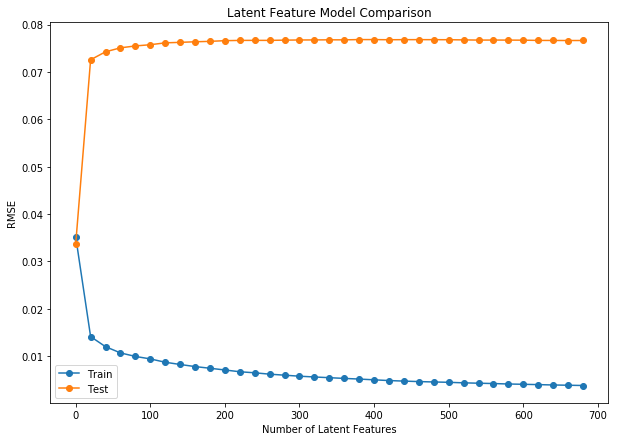

```python
# create array for number of latent features and empty lists to store train and test errors
latent_features = np.arange(0, 700, 20)
train_error = []
test_error = []

for k in latent_features:
    # slice the U, S, and Vt matrices to get k latent features from train and test data
    s_train_lat, u_train_lat, vt_train_lat = np.diag(s_train[:k]), u_train[:, :k], vt_train[:k, :]
    u_test_lat, vt_test_lat = u_test[:, :k], vt_test[:k, :]

    # regenerate train and test interaction matrices using k latent features
    interactions_matrix_train_preds = np.around(np.matmul(np.matmul(u_train_lat, s_train_lat), vt_train_lat))
    interactions_matrix_test_preds = np.around(np.matmul(np.matmul(u_test_lat, s_train_lat), vt_test_lat))

    # calculate the actual and predicted average rating for each song in the training data
    avg_rating_train = interactions_matrix_train.mean(axis=0)
    avg_rating_train_pred = interactions_matrix_train_preds.mean(axis=0)

    # calculate the actual and predicted average rating for each song in the test data
    avg_rating_test = interactions_matrix_test.mean(axis=0)
    avg_rating_test_pred = interactions_matrix_test_preds.mean(axis=0)

    # calculate train and test RMSE
    train_rmse = mean_squared_error(avg_rating_train, avg_rating_train_pred, squared=False)
    test_rmse = mean_squared_error(avg_rating_test, avg_rating_test_pred, squared=False)

    train_error.append(train_rmse)
    test_error.append(test_rmse)

# plotting train and test RMSE
plt.figure(figsize=(10,7))
plt.title('Latent Feature Model Comparison')
plt.plot(latent_features, train_error, label='Train', marker='o');
plt.plot(latent_features, test_error, label='Test', marker='o');
plt.xlabel('Number of Latent Features');
plt.ylabel('RMSE');
plt.legend();

# latent features
plt.show()
```

```python
# rerun model with set number of latent features = 10
s_10, u_10, vt_10 = np.diag(s[:10]), u[:, :10], vt[:10, :]
song_predicted_plays_10 = np.around(np.matmul(np.matmul(u_10, s_10), vt_10))
song_predicted_plays_10 = pd.DataFrame(abs(song_predicted_plays_10), columns = interactions_matrix.columns, index = interactions_matrix.index)
song_predicted_plays_10.head()
```

| song_id user_id | 6 | 64 | 66 | 146 | 174 | 296 | 328 | 428 | 500 | 550 | ... | 438363 | 438601 | 438647 | 438670 | 438709 | 438731 | 438741 | 438878 | 438887 | 438972 |
| --- | --- | --- | --- | --- | --- | --- | --- | --- | --- | --- | --- | --- | --- | --- | --- | --- | --- | --- | --- | --- | --- |
| 7 | 0.0 | 0.0 | 0.0 | 0.0 | 0.0 | 0.0 | 0.0 | 0.0 | 0.0 | 0.0 | ... | 0.0 | 0.0 | 0.0 | 0.0 | 0.0 | 0.0 | 0.0 | 0.0 | 0.0 | 0.0 |
| 10 | 0.0 | 0.0 | 0.0 | 0.0 | 0.0 | 0.0 | 0.0 | 0.0 | 0.0 | 0.0 | ... | 0.0 | 0.0 | 0.0 | 0.0 | 0.0 | 0.0 | 0.0 | 0.0 | 0.0 | 0.0 |
| 13 | 0.0 | 0.0 | 0.0 | 0.0 | 0.0 | 0.0 | 0.0 | 0.0 | 0.0 | 0.0 | ... | 0.0 | 0.0 | 0.0 | 0.0 | 0.0 | 0.0 | 0.0 | 0.0 | 0.0 | 0.0 |
| 16 | 0.0 | 0.0 | 0.0 | 0.0 | 0.0 | 0.0 | 0.0 | 0.0 | 0.0 | 0.0 | ... | 0.0 | 0.0 | 0.0 | 0.0 | 0.0 | 0.0 | 0.0 | 0.0 | 0.0 | 0.0 |
| 19 | 0.0 | 0.0 | 0.0 | 0.0 | 0.0 | 0.0 | 0.0 | 0.0 | 0.0 | 0.0 | ... | 0.0 | 0.0 | 0.0 | 0.0 | 0.0 | 0.0 | 0.0 | 0.0 | 0.0 | 0.0 |

5 rows × 7887 columns

```python
# rerun model with set number of latent features = 20
s_20, u_20, vt_20 = np.diag(s[:20]), u[:, :20], vt[:20, :]
song_predicted_plays_20 = np.around(np.matmul(np.matmul(u_20, s_20), vt_20))
song_predicted_plays_20 = pd.DataFrame(abs(song_predicted_plays_20), columns = interactions_matrix.columns, index = interactions_matrix.index)
song_predicted_plays_20.head()
```

| song_id user_id | 6 | 64 | 66 | 146 | 174 | 296 | 328 | 428 | 500 | 550 | ... | 438363 | 438601 | 438647 | 438670 | 438709 | 438731 | 438741 | 438878 | 438887 | 438972 |
| --- | --- | --- | --- | --- | --- | --- | --- | --- | --- | --- | --- | --- | --- | --- | --- | --- | --- | --- | --- | --- | --- |
| 7 | 0.0 | 0.0 | 0.0 | 0.0 | 0.0 | 0.0 | 0.0 | 0.0 | 0.0 | 0.0 | ... | 0.0 | 0.0 | 0.0 | 0.0 | 0.0 | 0.0 | 0.0 | 0.0 | 0.0 | 0.0 |
| 10 | 0.0 | 0.0 | 0.0 | 0.0 | 0.0 | 0.0 | 0.0 | 0.0 | 0.0 | 0.0 | ... | 0.0 | 0.0 | 0.0 | 0.0 | 0.0 | 0.0 | 0.0 | 0.0 | 0.0 | 0.0 |
| 13 | 0.0 | 0.0 | 0.0 | 0.0 | 0.0 | 0.0 | 0.0 | 0.0 | 0.0 | 0.0 | ... | 0.0 | 0.0 | 0.0 | 0.0 | 0.0 | 0.0 | 0.0 | 0.0 | 0.0 | 0.0 |
| 16 | 0.0 | 0.0 | 0.0 | 0.0 | 0.0 | 0.0 | 0.0 | 0.0 | 0.0 | 0.0 | ... | 0.0 | 0.0 | 0.0 | 0.0 | 0.0 | 0.0 | 0.0 | 0.0 | 0.0 | 0.0 |
| 19 | 0.0 | 0.0 | 0.0 | 0.0 | 0.0 | 0.0 | 0.0 | 0.0 | 0.0 | 0.0 | ... | 0.0 | 0.0 | 0.0 | 0.0 | 0.0 | 0.0 | 0.0 | 0.0 | 0.0 | 0.0 |

5 rows × 7887 columns

```python
# rerun model with set number of latent features = 40
s_40, u_40, vt_40 = np.diag(s[:40]), u[:, :40], vt[:40, :]
song_predicted_plays_40 = np.around(np.matmul(np.matmul(u_40, s_40), vt_40))
song_predicted_plays_40 = pd.DataFrame(abs(song_predicted_plays_40), columns = interactions_matrix.columns, index = interactions_matrix.index)
song_predicted_plays_40.head()
```

| song_id user_id | 6 | 64 | 66 | 146 | 174 | 296 | 328 | 428 | 500 | 550 | ... | 438363 | 438601 | 438647 | 438670 | 438709 | 438731 | 438741 | 438878 | 438887 | 438972 |
| --- | --- | --- | --- | --- | --- | --- | --- | --- | --- | --- | --- | --- | --- | --- | --- | --- | --- | --- | --- | --- | --- |
| 7 | 0.0 | 0.0 | 0.0 | 0.0 | 0.0 | 0.0 | 0.0 | 0.0 | 0.0 | 0.0 | ... | 0.0 | 0.0 | 0.0 | 0.0 | 0.0 | 0.0 | 0.0 | 0.0 | 0.0 | 0.0 |
| 10 | 0.0 | 0.0 | 0.0 | 0.0 | 0.0 | 0.0 | 0.0 | 0.0 | 0.0 | 0.0 | ... | 0.0 | 0.0 | 0.0 | 0.0 | 0.0 | 0.0 | 0.0 | 0.0 | 0.0 | 0.0 |
| 13 | 0.0 | 0.0 | 0.0 | 0.0 | 0.0 | 0.0 | 0.0 | 0.0 | 0.0 | 0.0 | ... | 0.0 | 0.0 | 0.0 | 0.0 | 0.0 | 0.0 | 0.0 | 0.0 | 0.0 | 0.0 |
| 16 | 0.0 | 0.0 | 0.0 | 0.0 | 0.0 | 0.0 | 0.0 | 0.0 | 0.0 | 0.0 | ... | 0.0 | 0.0 | 0.0 | 0.0 | 0.0 | 0.0 | 0.0 | 0.0 | 0.0 | 0.0 |
| 19 | 0.0 | 0.0 | 0.0 | 0.0 | 0.0 | 0.0 | 0.0 | 0.0 | 0.0 | 0.0 | ... | 0.0 | 0.0 | 0.0 | 0.0 | 0.0 | 0.0 | 0.0 | 0.0 | 0.0 | 0.0 |

5 rows × 7887 columns

```python
# recommend the songs with the highest predicted plays
def recommend_songs(user_idx, interactions_matrix, preds_df, num_recommendations):

    # Get and sort the user's ratings from the actual and predicted interaction matrix
    sorted_user_plays = interactions_matrix.iloc[user_idx].sort_values(ascending=False)
    sorted_user_predictions = preds_df.iloc[user_idx].sort_values(ascending=False)

    #Creating a dataframe with actual and predicted ratings columns
    temp = pd.concat([sorted_user_plays, sorted_user_predictions], axis=1)
    temp.index.name = 'Recommended Songs'
    temp.columns = ['user_plays', 'user_predictions']

    #Filtering the dataframe where actual ratings are 0 which implies that the user has not interacted with that movie
    temp = temp.loc[temp.user_plays == 0]

    #Recommending movies with top predicted ratings
    temp = temp.sort_values('user_predictions', ascending=False)
    print('\nBelow are the recommended songs for user(user_id = {}):\n'.format(user_idx))
    print(temp['user_predictions'].head(num_recommendations))
```

```python
# return predicted number of plays, sorted by highest
recommend_songs(3125, interactions_matrix, song_predicted_plays_10, 5)
```

```
Below are the recommended songs for user(user_id = 3125):

Recommended Songs
365178    2.0
329904    1.0
15080     1.0
350728    1.0
297789    0.0
Name: user_predictions, dtype: float64
```

```python
# display song information based on song id
song_df[song_df['song_id'].isin([365178, 329904, 15080, 350728, 297789])]
```

|  | song_id | title | release | artist_name | year |
| --- | --- | --- | --- | --- | --- |
| 111102 | 15080 | Undo | Vespertine Live | Björk | 2001 |
| 419297 | 350728 | Invalid | Fermi Paradox | Tub Ring | 2002 |
| 865618 | 329904 | Revelry | Only By The Night | Kings Of Leon | 2008 |
| 984786 | 297789 | Waiting For A Dream | Want | Rufus Wainwright | 2004 |

```python
# create a dataframe containing average actual plays and avearge predicted plays of the songs
rmse_df = pd.concat([interactions_matrix.mean(), song_predicted_plays_10.mean(),
                     song_predicted_plays_20.mean(), song_predicted_plays_40.mean()], axis=1)
rmse_df.columns = ['avg_actual_plays', 'avg_predicted_plays_10', 'avg_predicted_plays_20', 'avg_predicted_plays_40']
rmse_df.head()
```

| song_id | avg_actual_plays | avg_predicted_plays_10 | avg_predicted_plays_20 | avg_predicted_plays_40 |
| --- | --- | --- | --- | --- |
| 6 | 0.004607 | 0.000000 | 0.000000 | 0.000105 |
| 64 | 0.002199 | 0.000000 | 0.000000 | 0.000052 |
| 66 | 0.001361 | 0.000000 | 0.000000 | 0.000000 |
| 146 | 0.003350 | 0.000000 | 0.000000 | 0.000000 |
| 174 | 0.016542 | 0.000052 | 0.000157 | 0.000209 |

```python
# low RMSE means predictions are close to actual number of plays
RMSE_10 = mean_squared_error(rmse_df['avg_actual_plays'], rmse_df['avg_predicted_plays_10'], squared=False)
RMSE_20 = mean_squared_error(rmse_df['avg_actual_plays'], rmse_df['avg_predicted_plays_20'], squared=False)
RMSE_40 = mean_squared_error(rmse_df['avg_actual_plays'], rmse_df['avg_predicted_plays_40'], squared=False)

print('\nRMSE SVD Model: 10 Latent Features = {} \n'.format(RMSE_10))
print('\nRMSE SVD Model: 20 Latent Features = {} \n'.format(RMSE_20))
print('\nRMSE SVD Model: 40 Latent Features = {} \n'.format(RMSE_40))
```

```
RMSE SVD Model: 10 Latent Features = 0.019779776303072743


RMSE SVD Model: 20 Latent Features = 0.017045863739923076


RMSE SVD Model: 40 Latent Features = 0.014384358016931222
```

## 5. Full Implementation: Combing Methods

```python
# recommend the songs with the highest predicted plays
def recommend_songs_2(user_idx, interactions_matrix, preds_df, num_recommendations):

    # get and sort the user's ratings from the actual and predicted interaction matrix
    sorted_user_plays = interactions_matrix.iloc[user_idx].sort_values(ascending=False)
    sorted_user_predictions = preds_df.iloc[user_idx].sort_values(ascending=False)

    # create a dataframe with actual and predicted plays columns
    temp = pd.concat([sorted_user_plays, sorted_user_predictions], axis=1)
    temp.index.name = 'Recommended Songs'
    temp.columns = ['user_plays', 'user_predictions']

    # filter the dataframe where actual ratings are 0 which implies that the user has not interacted with that song
    temp = temp.loc[temp.user_plays == 0]

    # recommend songs with top predicted plays
    temp = temp.sort_values('user_predictions', ascending=False)
    # modified return value so that it can be used as an object later
    return temp.index[:num_recommendations]
```

```python
def hybrid_recs(user_id, num_recommendations):
    # use collaborative filtering for first set of recs
    cf_recs = recommendations(user_id, num_recommendations, interactions_matrix)

    # use matrix estimation for second set of recs
    svd_recs = list(recommend_songs_2(user_id, interactions_matrix, song_predicted_plays_40, num_recommendations))

    # combine all recs and keep unique ids
    all_recs = np.unique(cf_recs+svd_recs)

    # display combined recommended songs for the given user
    return song_df[song_df['song_id'].isin(all_recs)]
```

```python
hybrid_recs(19, 10)
```

|  | song_id | title | release | artist_name | year |
| --- | --- | --- | --- | --- | --- |
| 111102 | 15080 | Undo | Vespertine Live | Björk | 2001 |
| 123276 | 409081 | Masquerade (Reality Check Album Version) | Reality Check | Reality Check | 1997 |
| 363835 | 179016 | Up | My Worlds | Justin Bieber | 2010 |
| 611449 | 218691 | Le Jardin d'Hiver | Smile | Jacky Terrasson | 2002 |
| 921367 | 380325 | Ave Maria | I AM...SASHA FIERCE | Beyoncé | 2008 |
| 930877 | 345146 | Marry Me | Save Me_ San Francisco | Train | 2009 |